# data609hw1

jim lung

September 4, 2018

# Page 8: #10

Your grandparents have an annuity. The value of the annuity increases each month by an automatic deposit of 1% interest on the previous month’s balance. Your grandparents withdraw $1000 at the beginning of each month for living expenses. Currently, they have $50,000 in the annuity. Model the annuity with a dynamical system. Will the annuity run out of money? When? Hint: What value will $a_{n}$ have when the annuity is depleted?

$a_{n} = a_{n-1} + 0.01a_{n-1} - 1000$  
$a_{n+1} = a_{n} + 0.01a_{n} - 1000$

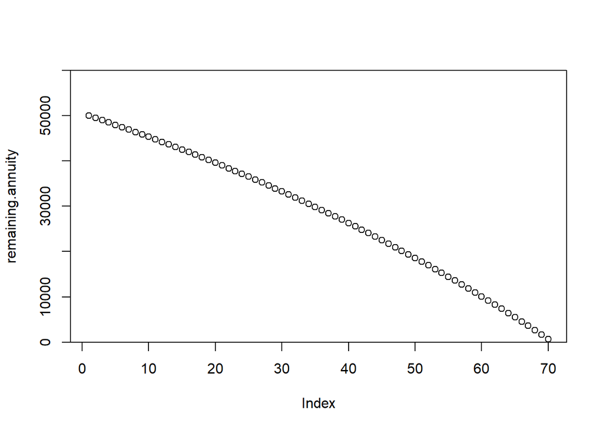

```r
steps = 100
n_0 = 50000
withdrawl = 1000
percent_return = 1

annuity <- function(x){x + (percent_return/100)*x - withdrawl}

remaining.annuity <- n_0

for (i in 1:steps) {
  n = annuity(remaining.annuity[i])
  remaining.annuity <- c(remaining.annuity,n)}

remaining.annuity <- remaining.annuity[which(remaining.annuity > 0)]
plot(remaining.annuity, ylim = c(0, n_0 + 10000),yaxs = "i")
```

```r
which.min(remaining.annuity)
```

```
## [1] 70
```

*Note: I could rewrite this solution using a ‘where’ loop as I do in the third problem. This would eliminate the need to guess at the number of steps that need to be computed and would ensure only positive values for remaining.annuity.*

Checking my work analytically:

$a_{70} = (1.01)^{70}c+100,000$  
$2.0c=100,000$  
$c=50,000$

# Page 17: #9

The data in the accompanying table show the speed n (in increments of 5 mph) of an automobile and the associated distance $a_{n}$ in feet required to stop it once the brakes are applied. For instance, n=6 (representing 6 x 5 = 30 mph) requires a stopping distance of $a_{6} = 47 ft$. a. Calculate and plot the change $\Delta a_{n}$ versus n. Does the graph reasonably approximate a linear relationship? b. Based on your conclusions in part (a), find a difference equation model for the stopping distance data. Test your model by plotting the errors in the predicted values against n. Discuss the appropriateness of the model.

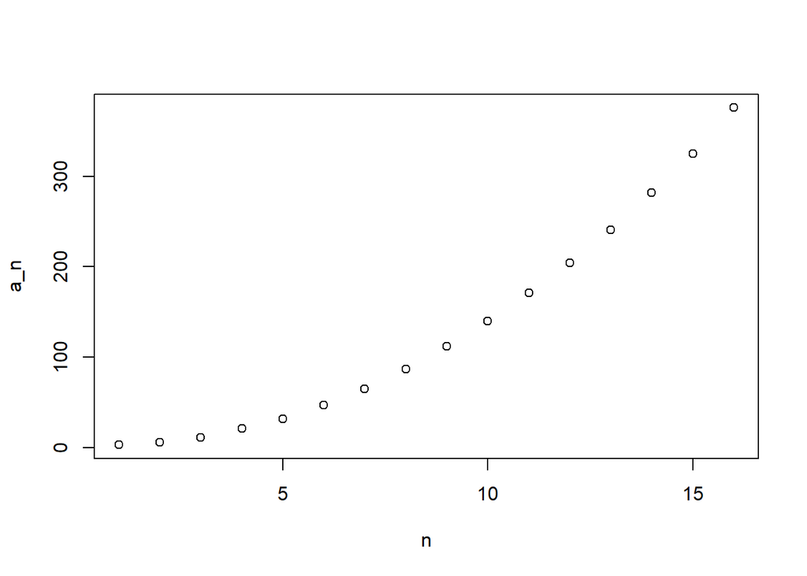

```r
n = seq(1,16,1)
a_n = c(3,6,11,21,32,47,65,87,112,140,171,204,241,282,325,376)

delta_a <- diff(a_n)
plot(x = n, y = a_n)
```

The change in braking distance at different speeds is well approximated by a linear model.

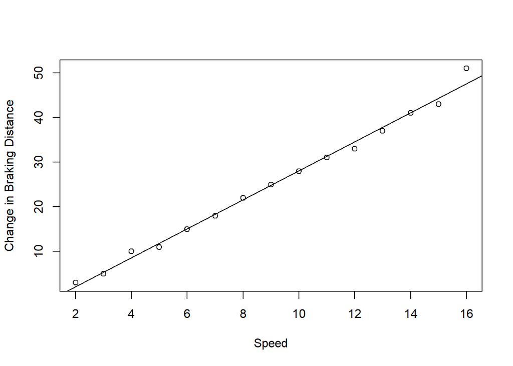

```r
braking.model <- lm(delta_a ~ n[2:16] )

plot(x = n[2:16], y = delta_a, xlab = 'Speed', ylab = 'Change in Braking Distance')
abline(braking.model)
```

```r
k <- as.numeric(braking.model$coefficients[2])
print(k)
```

```
## [1] 3.246429
```

Model: $\Delta a_{n} = 3.246n$

Predicted stopping distances:

```r
model <- function(n, a, k){
  an <- k * n + a
  return(an)}

model.result <- NULL
model.result[1] <- 0
for (i in 2:length(a_n)) {
  model.result[i] <- model(i, model.result[i - 1], k)}
```

The model error increases as speed increases.

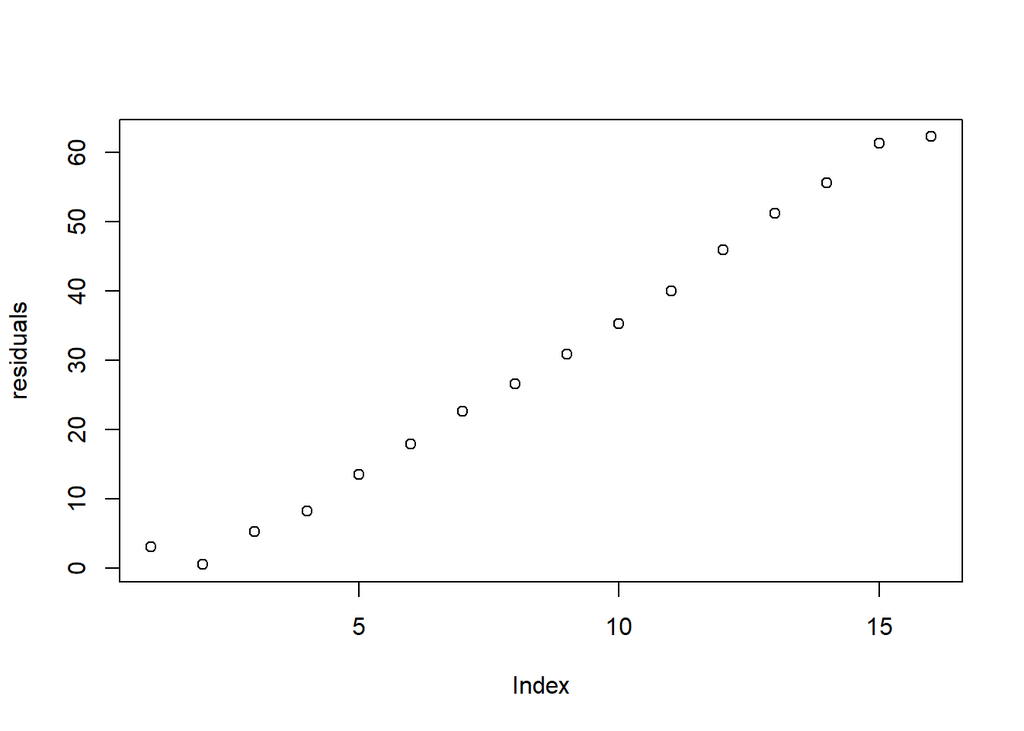

```r
residuals <- abs(a_n - model.result)
plot(residuals)
```

# Page 34: #13

Consider the spreading of a rumor through a company of 1000 employees, all working in the same building. We assume that the spreading of a rumor is similar to the spreading of a contagious disease (see Example 3, Section 1.2) in that the number of people hearing the rumor each day is proportional to the product of the number who have heard the rumor previously and the number who have not heard the rumor. This is given by $r_{n+ 1} = r_{n} + kr_{n} (1000 - n )$ where k is a parameter that depends on how fast the rumor spreads and n is the number of days. Assume k=0.001 and further assume that four people initially have heard the rumor. How soon will all 1000 employees have heard the rumor?

```r
# set parameters
k = 0.001
r0 = 4
total.population = 1000

# calculate numer of employees who have heard rumor
# while ensuring it stays below the total population
heard <- r0
n = 1
while (heard < total.population) {
  heard <- heard + (k * heard * (1000 - n))
  n <- n + 1}
```

How soon will all 1000 employees have heard the rumor? In days:

```r
n
```

```
## [1] 9
```

# Page 55: #6

An economist is interested in the variation of the price of a single product. It is observed that a high price for the product in the market attracts more suppliers. However, increasing the quantity of the product supplied tends to drive the price down. Over time, there is an interaction between price and supply. The economist has proposed the following model, where $P_{n}$ represents the price of the product at year n, and $Q_{n}$ represents the quantity. Find the equilibrium values for this system.  
$P_{n+1} = P_{n} - 0.1(Q_{n}-500)$  
$Q_{n+1} = Q_{n} + 0.2(P_{n}-100)$

1. Does the model make sense intuitively? What is the significance of the constants 100 and 500? Explain the significance of the signs of the constants -0.1 and 0.2.

P = 100 and Q = 500 are the equilibrium values.

The constants 100 and 500 represent the prices/quantities where the buyers and producers get least sensitive to price and quantities (hence equilibrium at these values). (-0.1) and 0.2 represent the reaction of the buyers / producers to changes in the price / quantities.

```r
# set parameters
iter = 250
k.price = 0.1
k.quant = 0.2
equ.price = 500
equ.quant = 100

# model
price <- function(P_n, Q_n) {
  price.calc <- P_n - (k.price * (Q_n - equ.price))
  return(price.calc)}

quantity <- function(P_n, Q_n) {
  quantity.calc <- Q_n + (k.quant * (P_n - equ.quant))
  return(quantity.calc)}

model.call <- function(P_n1, Q_n1){
    P_n <- c()
    P_n[1] <- P_n1

    Q_n <- c()
    Q_n[1] <- Q_n1
      for (i in 1:iter) {
        P_n[i + 1] <- price(P_n[i], Q_n[i])
        Q_n[i + 1] <- quantity(P_n[i], Q_n[i])
    }
  sim <- seq(1,iter + 1)
  econ.model <- as.data.frame(cbind(P_n, Q_n, sim))
  return(econ.model)
  }
```

2. Test the initial conditions in the following table and predict the long-term behavior.

```r
library(ggplot2)
```

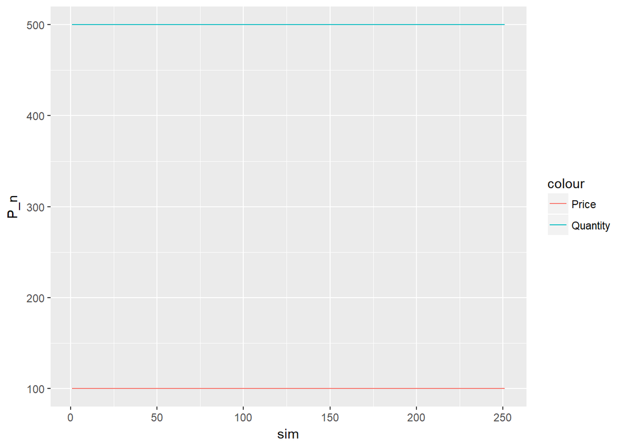

```r
case.A <- model.call(100, 500)

ggplot(case.A, aes(sim)) +
  geom_line(aes(y = P_n, colour = "Price")) +
  geom_line(aes(y = Q_n, colour = "Quantity"))
```

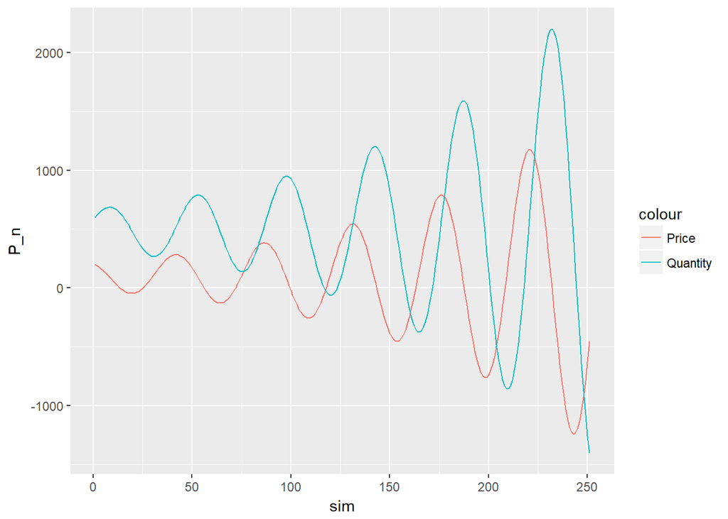

```r
case.B <- model.call(200, 600)

ggplot(case.B, aes(sim)) +
  geom_line(aes(y = P_n, colour = "Price")) +
  geom_line(aes(y = Q_n, colour = "Quantity"))
```

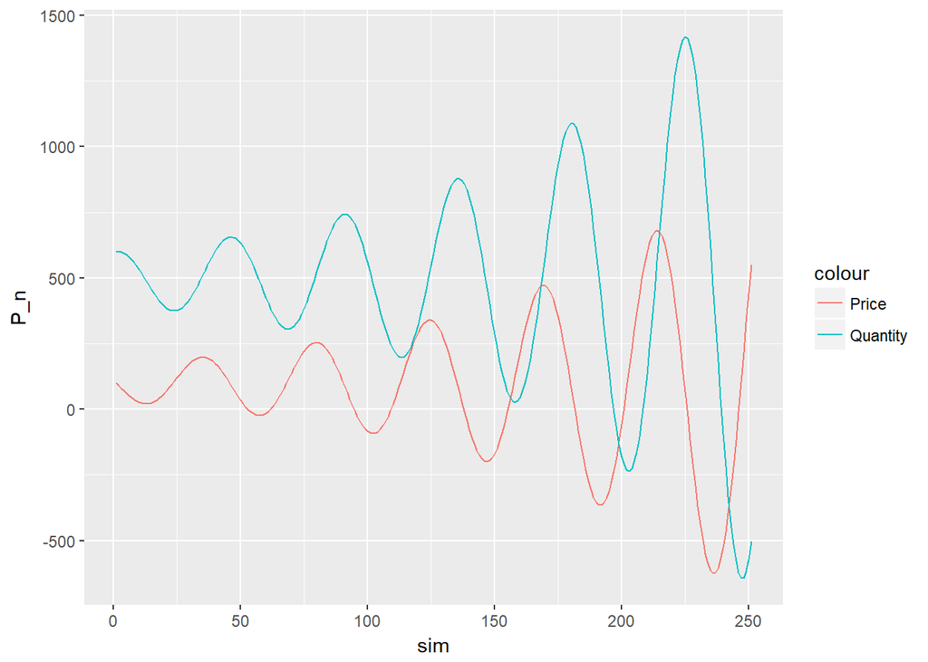

```r
case.C <- model.call(100, 600)

ggplot(case.C, aes(sim)) +
  geom_line(aes(y = P_n, colour = "Price")) +
  geom_line(aes(y = Q_n, colour = "Quantity"))
```

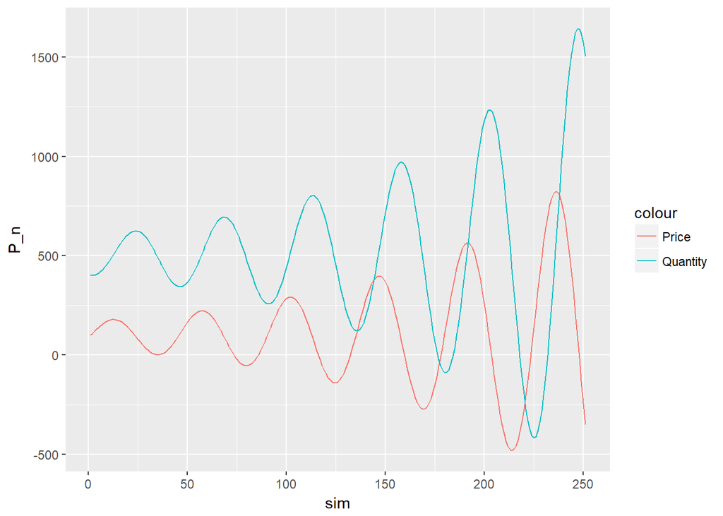

```r
case.D <- model.call(100, 400)

ggplot(case.D, aes(sim)) +
  geom_line(aes(y = P_n, colour = "Price")) +
  geom_line(aes(y = Q_n, colour = "Quantity"))
```